# Lecture 2: Exploratory Data Analysis

### We can also generate our own gradients using colorRampPalette. Note that colorRampPalette returns a function that we can use to generate as many colors from that palette as we need.

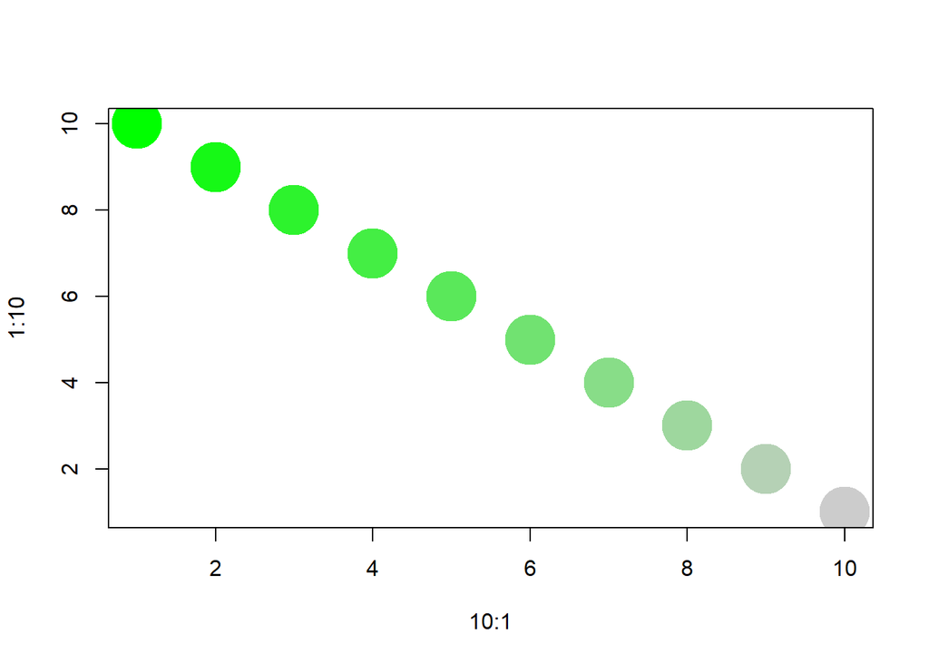

```r
palf <- colorRampPalette(c("gray80", "green"))

plot(x=10:1, y=1:10, pch=19, cex=5, col=palf(10))
```

### To add transparency to colorRampPalette, you need to use a parameter alpha=TRUE:

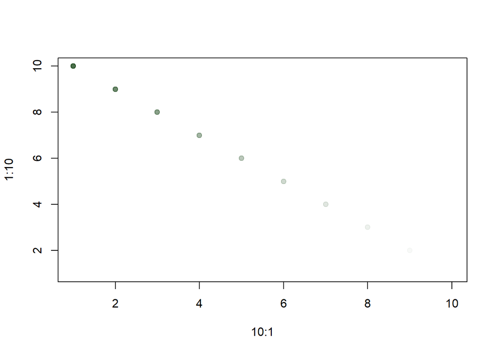

```r
palf <- colorRampPalette(c(rgb(1,1,1, .2),rgb(0,0.2,0, .7)), alpha=TRUE)

plot(x=10:1, y=1:10, pch=19, cex=1, col=palf(10))
```

# 2.3. Simple Base Graphics

## Iris Dataset

```r
DataX = iris
str(DataX)
```

```
## 'data.frame':    150 obs. of  5 variables:
##  $ Sepal.Length: num  5.1 4.9 4.7 4.6 5 5.4 4.6 5 4.4 4.9 ...
##  $ Sepal.Width : num  3.5 3 3.2 3.1 3.6 3.9 3.4 3.4 2.9 3.1 ...
##  $ Petal.Length: num  1.4 1.4 1.3 1.5 1.4 1.7 1.4 1.5 1.4 1.5 ...
##  $ Petal.Width : num  0.2 0.2 0.2 0.2 0.2 0.4 0.3 0.2 0.2 0.1 ...
##  $ Species     : Factor w/ 3 levels "setosa","versicolor",..: 1 1 1 1 1 1 1 1 1 1 ...
```

```r
#DataX$Species
dim(DataX)
```

```
## [1] 150   5
```

```r
head(DataX)
```

```
##   Sepal.Length Sepal.Width Petal.Length Petal.Width Species
## 1          5.1         3.5          1.4         0.2  setosa
## 2          4.9         3.0          1.4         0.2  setosa
## 3          4.7         3.2          1.3         0.2  setosa
## 4          4.6         3.1          1.5         0.2  setosa
## 5          5.0         3.6          1.4         0.2  setosa
## 6          5.4         3.9          1.7         0.4  setosa
```

```r
summary(DataX)
```

```
##   Sepal.Length    Sepal.Width     Petal.Length    Petal.Width
##  Min.   :4.300   Min.   :2.000   Min.   :1.000   Min.   :0.100
##  1st Qu.:5.100   1st Qu.:2.800   1st Qu.:1.600   1st Qu.:0.300
##  Median :5.800   Median :3.000   Median :4.350   Median :1.300
##  Mean   :5.843   Mean   :3.057   Mean   :3.758   Mean   :1.199
##  3rd Qu.:6.400   3rd Qu.:3.300   3rd Qu.:5.100   3rd Qu.:1.800
##  Max.   :7.900   Max.   :4.400   Max.   :6.900   Max.   :2.500
##        Species
##  setosa    :50
##  versicolor:50
##  virginica :50
##
##
##
```

## Basic R Plots

### Histogram

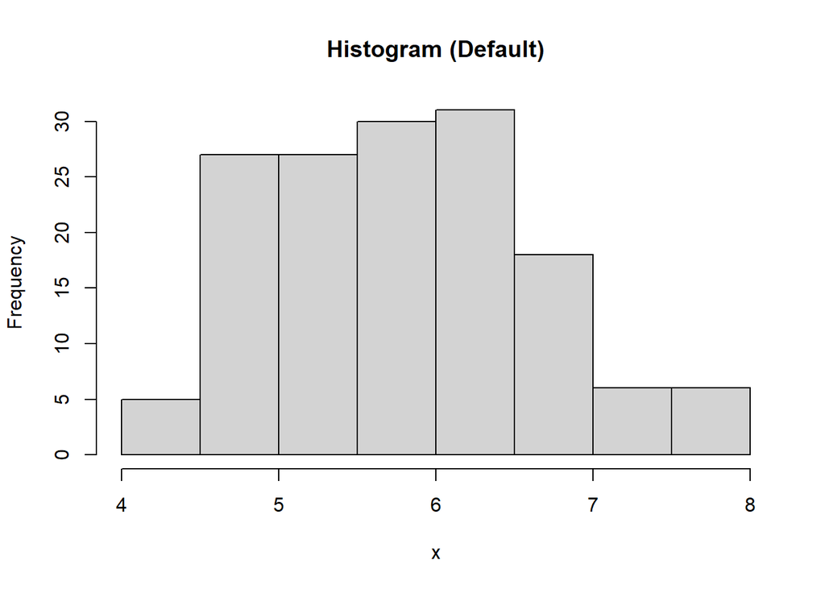

```r
x = DataX[,1]
hist(x, main='Histogram (Default)')
```

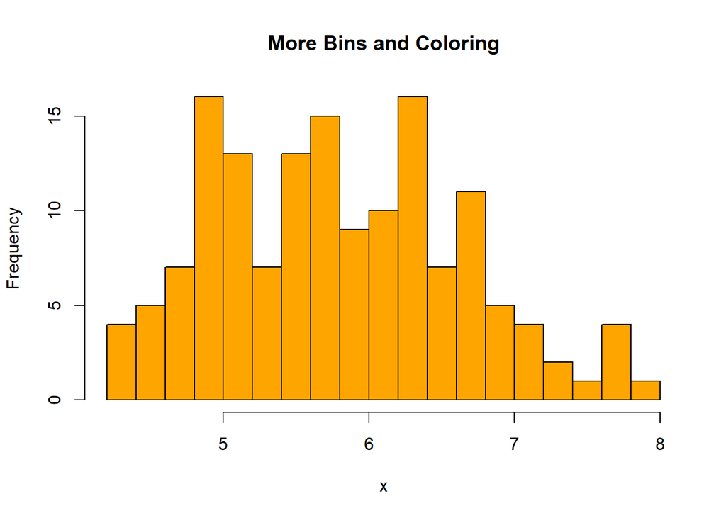

```r
hist(x, breaks=20, col="orange", main='More Bins and Coloring')
```

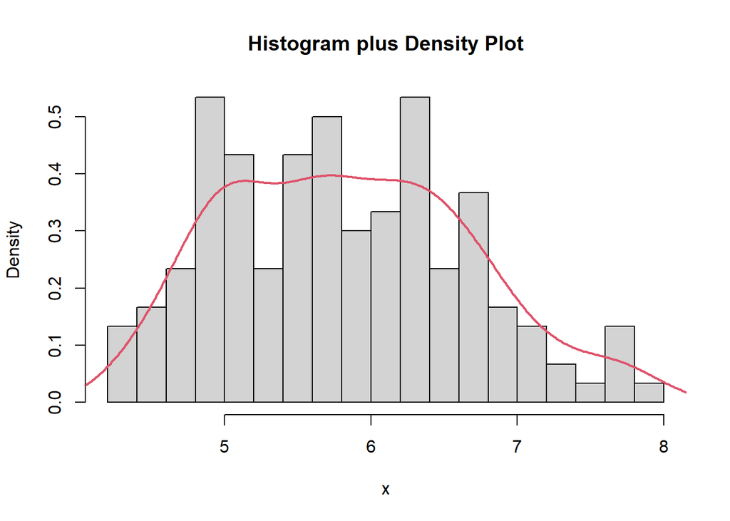

```r
hist(x, breaks=20, freq=F, main='Histogram plus Density Plot')   # using freq=FALSE
lines(density(x), col=2, lty=1, lwd=2)  #add the density curve
```

### Box plot

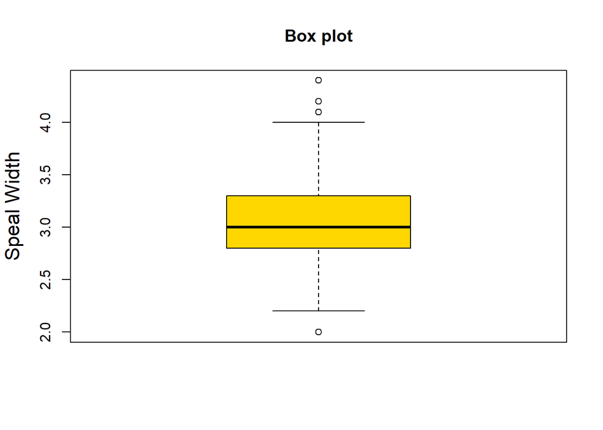

```r
x = DataX[,2]
boxplot(x,main="Box plot",col="gold")
mtext("Speal Width", side = 2, line = 2.8,cex=1.4)
```

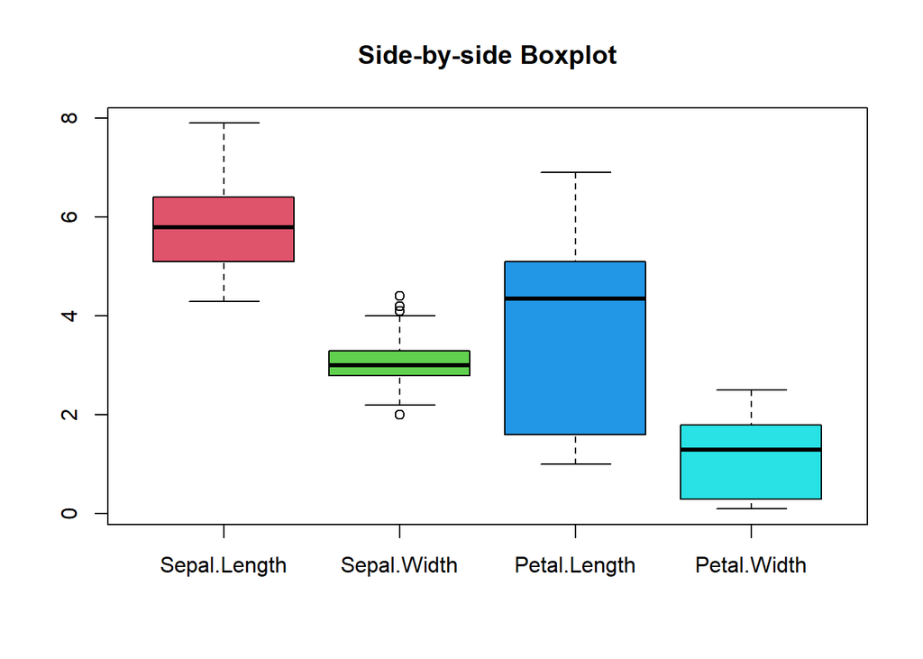

```r
boxplot(DataX[,1:4], col=c(2,3,4,5), main='Side-by-side Boxplot')
```

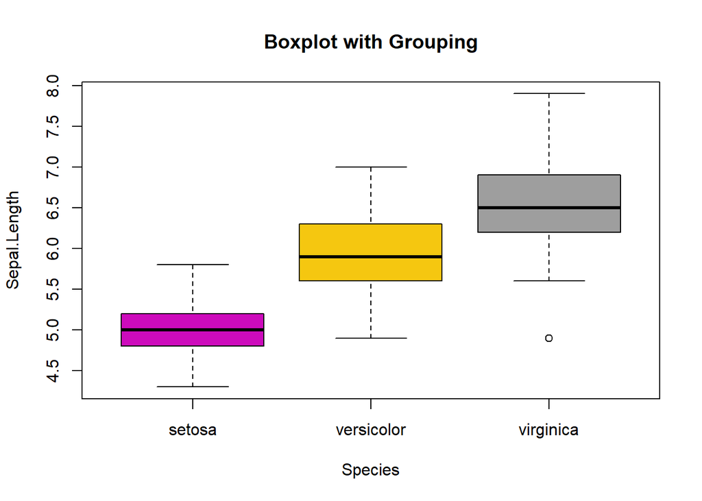

```r
boxplot(Sepal.Length~Species, DataX, col=c(6,7,8), main="Boxplot with Grouping")
```

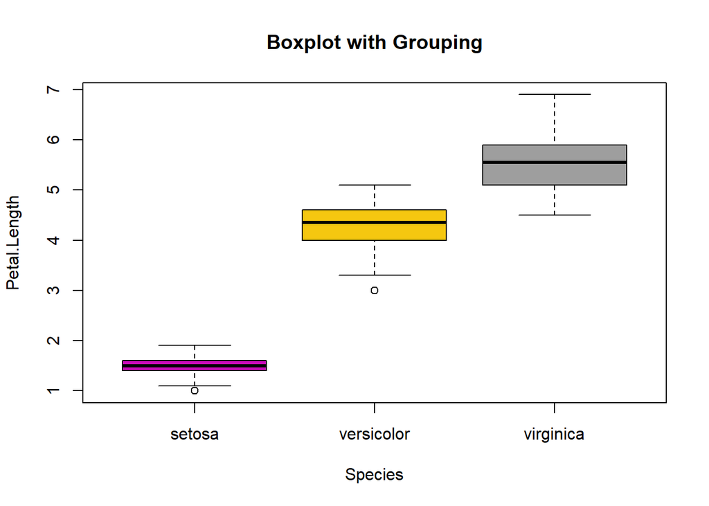

```r
boxplot(Petal.Length~Species, DataX, col=c(6,7,8), main="Boxplot with Grouping")
```

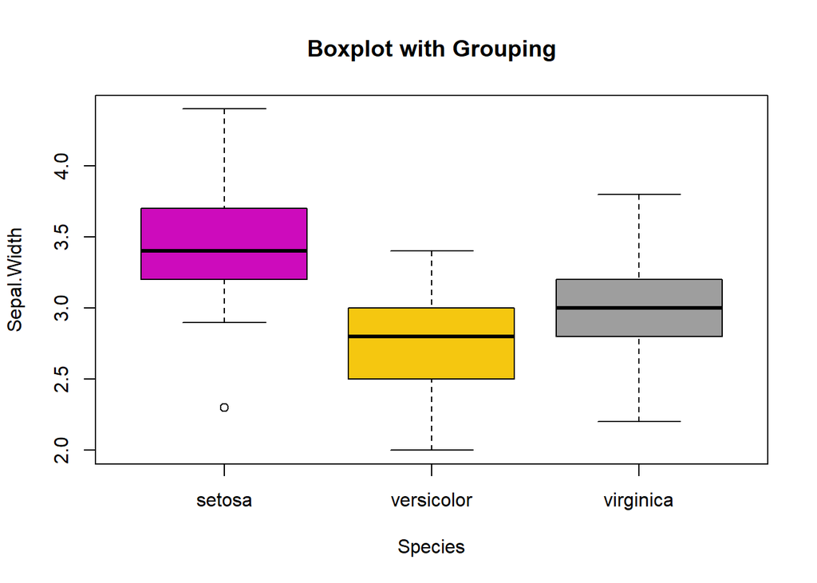

```r
boxplot(Sepal.Width~Species, DataX, col=c(6,7,8), main="Boxplot with Grouping")
```

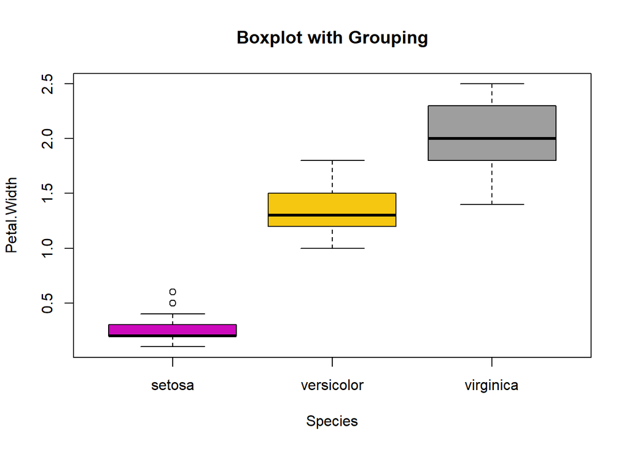

```r
boxplot(Petal.Width~Species, DataX, col=c(6,7,8), main="Boxplot with Grouping")
```

### Pie and Bar Charts

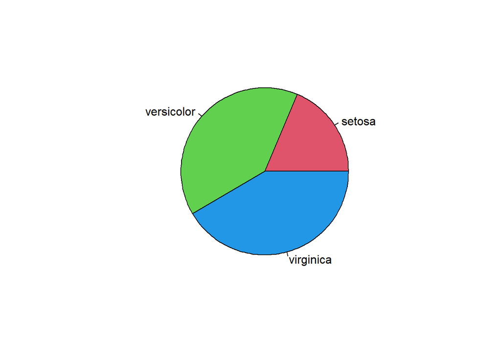

```r
DataX$Flag = DataX$Sepal.Length>5 # Create a binary flag
pie(table(DataX$Species[DataX$Flag]), col=c(2,3,4))
```

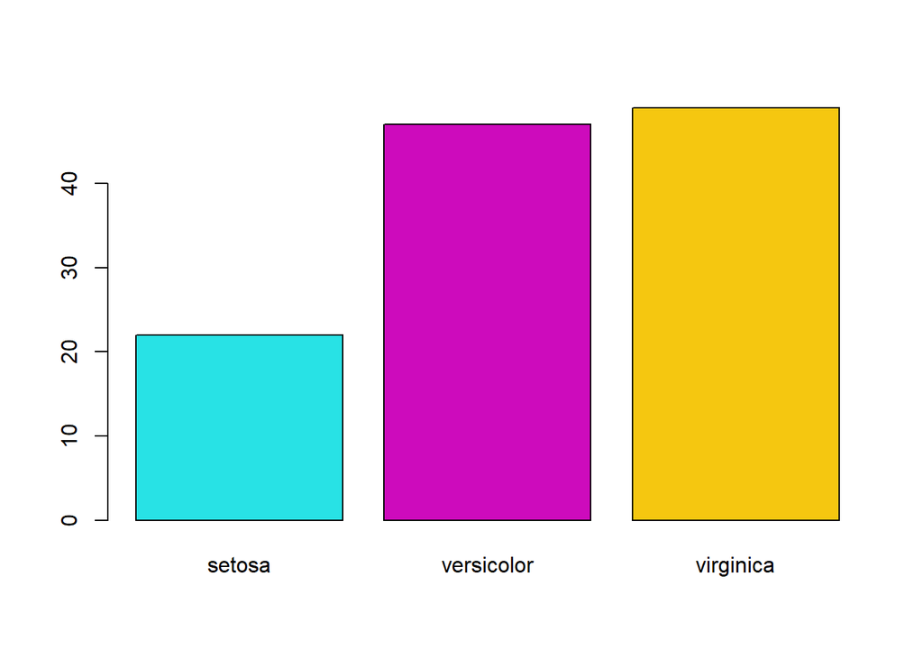

```r
barplot(table(DataX$Species[DataX$Flag]), col=c(5,6,7))
```

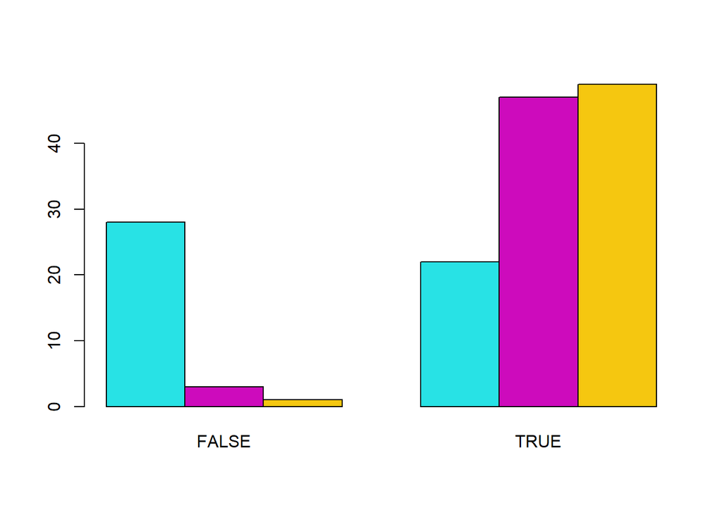

```r
barplot(table(DataX$Species, DataX$Flag), col=c(5,6,7), beside=T)
```

### Relationship Between Variables

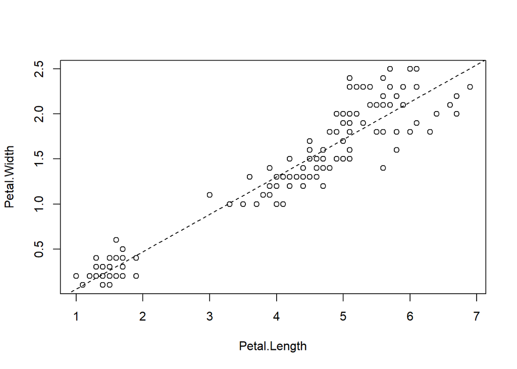

```r
x = DataX$Petal.Length; y = DataX$Petal.Width; z = DataX$Species
plot(x, y, xlab="Petal.Length", ylab="Petal.Width")
abline(coef(lm(y~x)), col=1, lty=2)
```

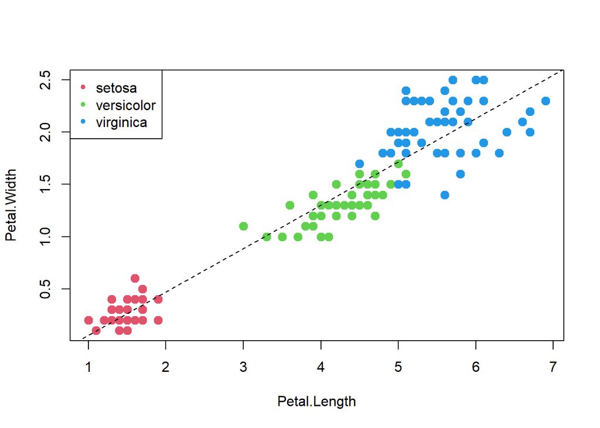

```r
plot(x, y, col=c(2,3,4)[z], pch=20, cex=2.0, xlab="Petal.Length", ylab="Petal.Width")
abline(lm(y~x), col=1, lty=2)
legend("topleft", levels(z), pch=20, col=c(2,3,4))
```

### Pairwise Scatter Plot

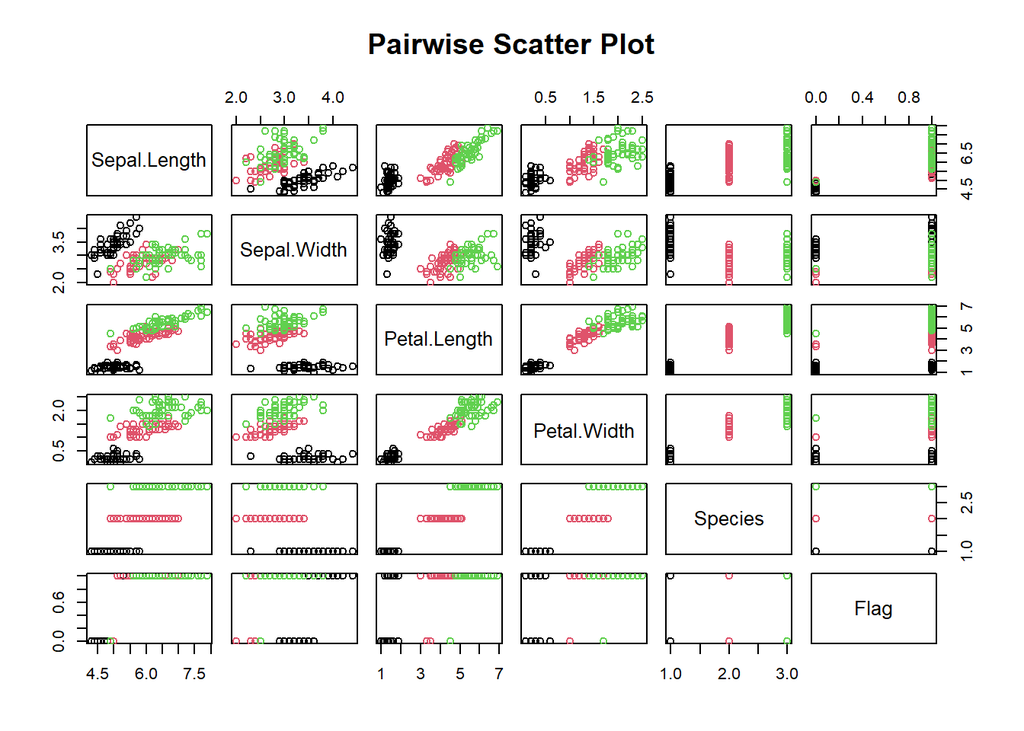

```r
plot(DataX, col=DataX$Species, main="Pairwise Scatter Plot")
```

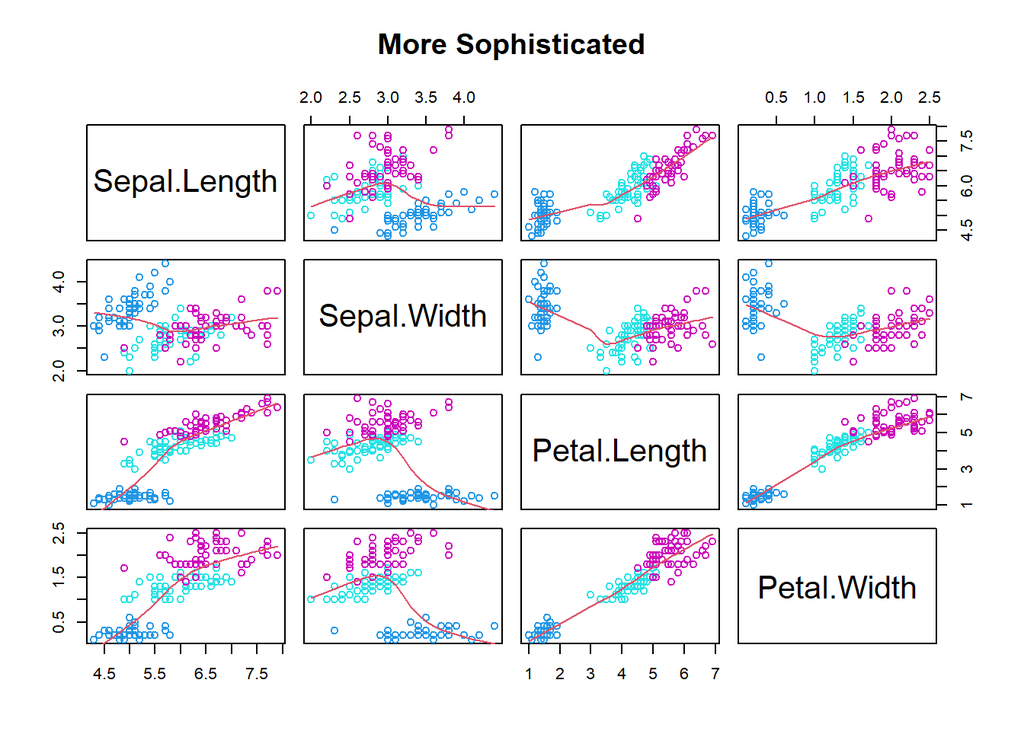

```r
pairs(DataX[,1:4], panel = panel.smooth, col = c(4,5,6)[DataX$Species], main="More Sophisticated")
```

### Bag Plot

### The bagplot consists of three nested polygons, called the “bag”, the “fence”, and the “loop”.

### The inner polygon, called the bag, is constructed on the basis of Tukey depth, the smallest number of observations that can be contained by a half-plane that also contains a given point.[4] It contains at most 50% of the data points.

### The outermost of the three polygons, called the fence is not drawn as part of the bagplot, but is used to construct it. It is formed by inflating the bag by a certain factor (usually 3). Observations outside the fence are flagged as outliers.

### The observations that are not marked as outliers are surrounded by a loop, the convex hull of the observations within the fence.

```r
library(aplpack)
```

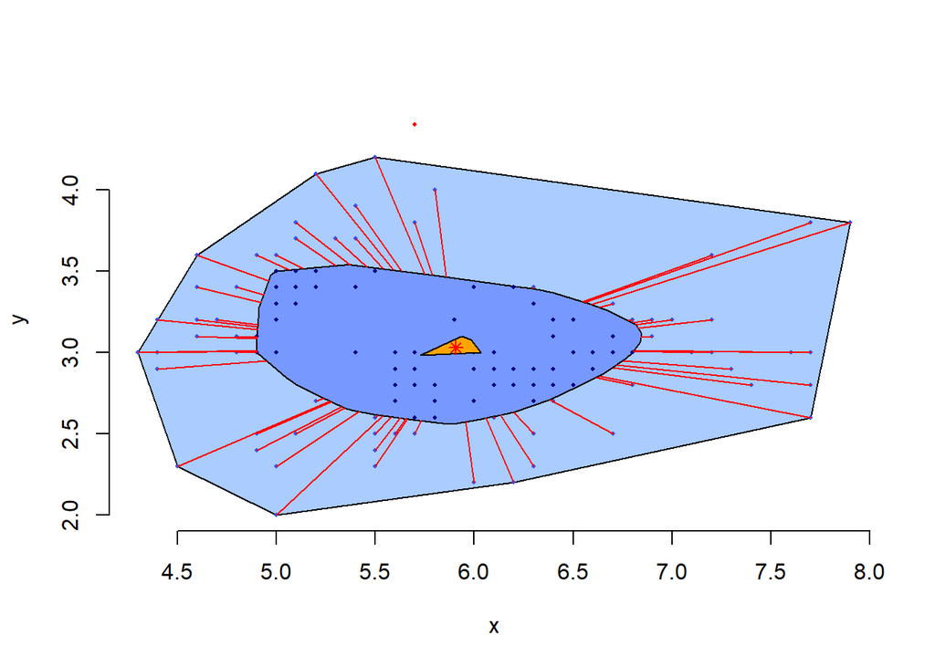

```r
bagplot(DataX[, 1:2])
```

### Violin Plot

### A violin plot is a hybrid of a box plot and a kernel density plot, which shows peaks in the data. It is used to visualize the distribution of numerical data. Unlike a box plot that can only show summary statistics, violin plots depict summary statistics and the density of each variable.

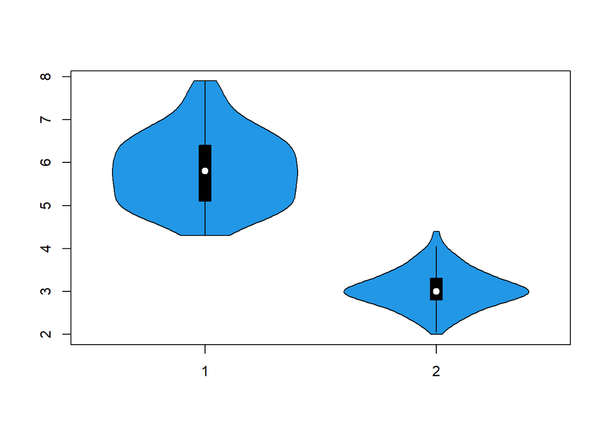

```r
library(vioplot)
vioplot(DataX[,1], DataX[,2],col=4)
```

# 2.4 Using R:Lattice Package

### Using trellis graphs for multivariate data

### Multipanel conditioning and grouping

### Elegant high-level data visualization

### Covering most of statistical charts

### Figures and Codes can be found at

### http://lmdvr.r-forge.r-project.org/

### However, plot customization are not so straightforward

## Univariate Distributions

```r
library(lattice); library(gridExtra)
```

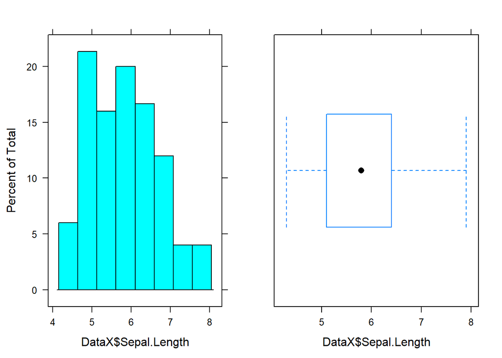

```r
p1 = histogram(DataX$Sepal.Length)
p2 = bwplot(DataX$Sepal.Length)
grid.arrange(p1, p2, ncol=2)
```

## Histogram with Conditioning

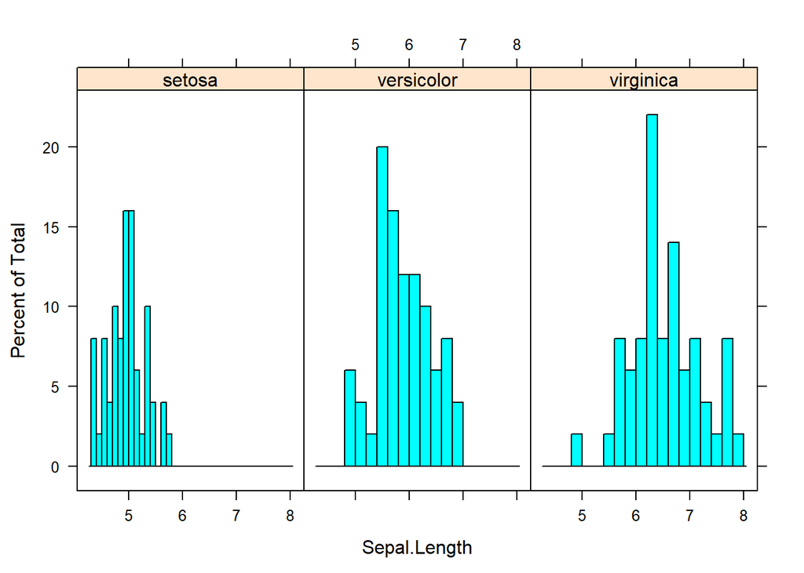

```r
histogram(data=DataX, ~Sepal.Length|Species, breaks=12, layout = c(3, 1))
```

## Density plot with Grouping

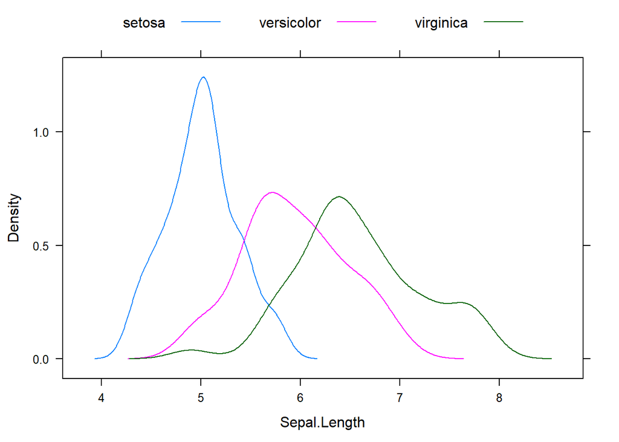

```r
densityplot(data=DataX, ~Sepal.Length, groups=Species,
            plot.points=F, auto.key=list(space="top", columns=3))
```

## Boxplot with Grouping

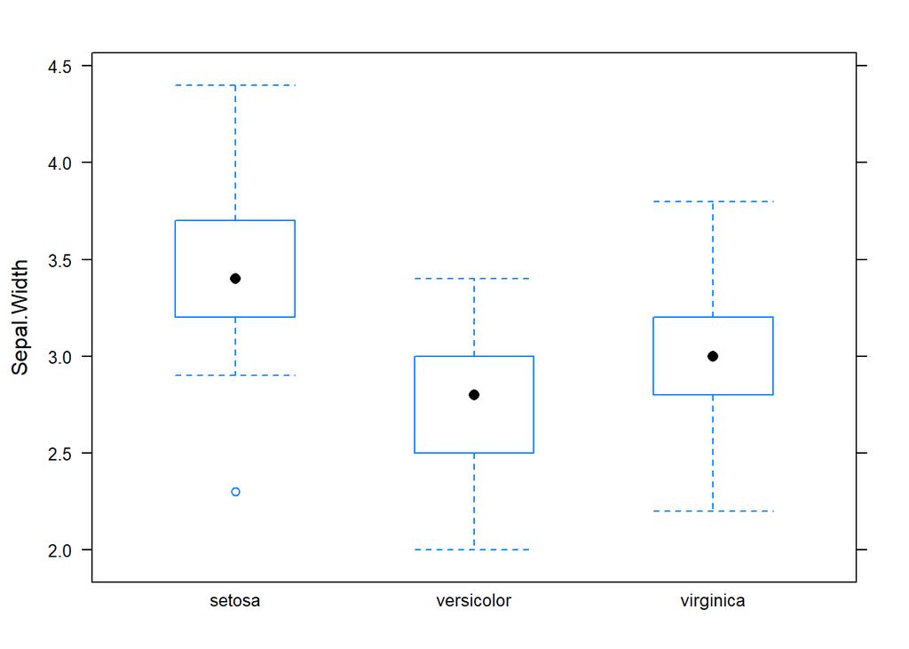

```r
bwplot(data=DataX, Sepal.Width~Species)
```

## Bivariate plot with Grouping

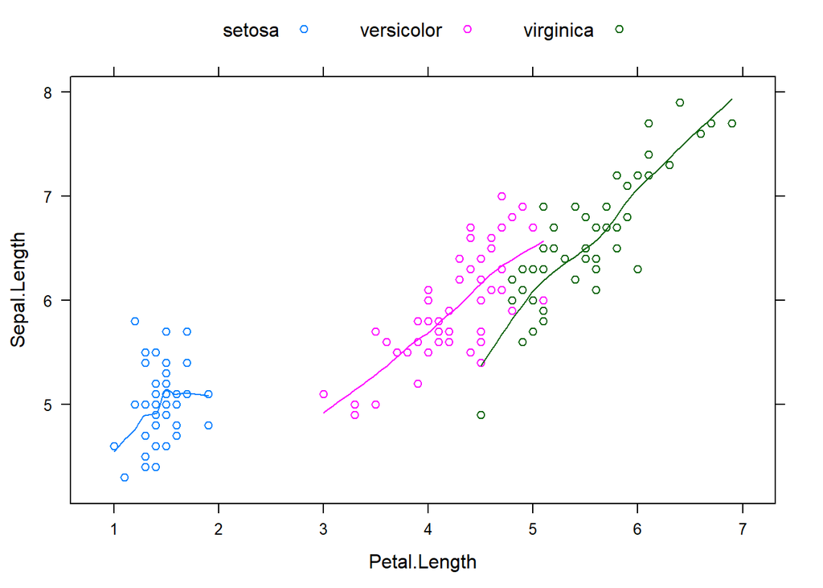

```r
xyplot(data=DataX, Sepal.Length ~ Petal.Length, groups = Species,
       type = c("p", "smooth"),
       auto.key = list(space="top", columns=3)) # grouping
```

## Bivariate plot with Conditioning

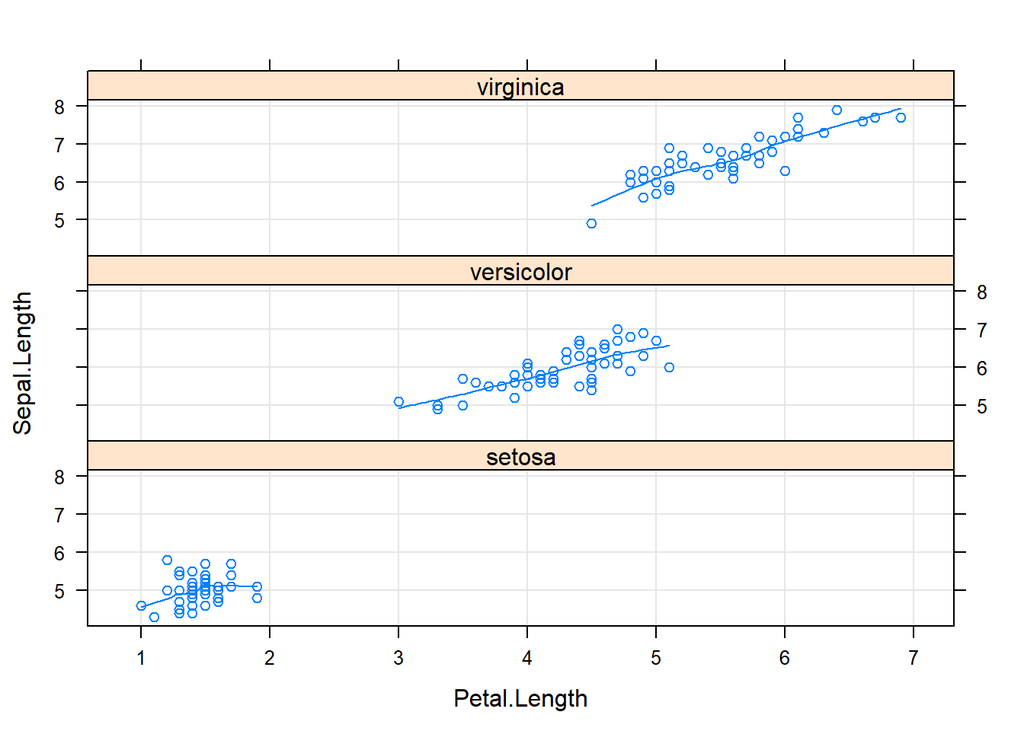

```r
xyplot(data=DataX, Sepal.Length ~ Petal.Length|Species,
       type=c("p", "smooth",  "g"), layout=c(1,3)) # conditioning
```